**Dragos Ailoae**

Applied Statistics and Econometrics I

2021-10-04

# Intro to Univariate Regression

## General Concepts

Much of econometric analysis begins with the following premise: let $Y$ and $X$ be two variables. We are interested in explaining $Y$ in terms of $X$. On the other hand, any single $X$ will never fully explain an economic variable $Y$. As such, all other non-observable factors, influencing $Y$, manifest themselves as an unpredictable (i.e. random) disturbance $\epsilon$. Thus, we are looking for a function $f$, which describes this relationship: $$ Y=f(X, \epsilon) $$ where:

- $Y$ - is the variable of interest (e.g. total production, revenue, etc.);
- $X$ - is a variable, which would help us explain $Y$ (examples of $X$ include labor input, number of hours worked, capital input, equipment quality, number of employees, raw materials etc.);

Furthermore:

- $f(\cdot)$ is called a regression function;
- $X$ is called the independent variable, the control variable, the explanatory variable, the predictor variable, or the regressor;
- $Y$ is called the dependent variable, the response variable, the explained variable, the predicted variable or the regressand;
- $\epsilon$ is called the random component, the error term, the disturbance or the (economic) shock. We will assume that $X$ is a random variable (though this may not always be the case). In any case, $Y$ is a random variable $(r . v .)$, which depends on $\epsilon(r . v .)$ and $X$. The simplest functional form of $f$ is linear:

\begin{equation} Y=\beta_{0}+\beta_{1} X+\epsilon \end{equation}

If this functional form is appropriate for the data, our goal is to estimate its unknown coefficients $\beta_{0}$ and $\beta_{1}$ from the available data sample. Usually, we will assume that we have a finite random sample $\left(X_{1}, Y_{1}\right), \ldots,\left(X_{N}, Y_{N}\right)$ of independent identically distributed (i.i.d.) r.v.'s (unless stated otherwise), with their realizations (observed values) $\left(x_{1}, y_{1}\right), \ldots,\left(x_{N}, y_{N}\right) .$ Since $\epsilon$ is a collection of unknown r.v.'s, unlike $X$ and $Y$, we do not observe $\epsilon$.

We expect that, on average, the relationship in (1) holds. The two-dimensional r.v. $(X, Y)$ is fully determined by the two-dimensional r.v. $(X, \epsilon) .$ In order to get good estimates of $\beta_{0}$ and $\beta_{1}$, we have to impose certain restrictions on the properties of $\epsilon$ and the interaction between $X$ and $\epsilon$.

We denote $\mathbb{E}(Y \mid X)$ - the conditional expectation of $Y$ on $X$ - an expectation of $Y$, provided we know the value of r.v. $X$

Equation (1) implies that if $\mathbb{E}(\epsilon \mid X)=0$, then the r.v. $Y=\beta_{0}+\beta_{1} X+\epsilon$ is on average $\beta_{0}+\beta_{1} X$ :

$$ \mathbb{E}\left(\beta_{0}+\beta_{1} X+\epsilon \mid X\right)=\beta_{0}+\beta_{1} X $$

and

- $\beta_{0}$ - the intercept parameter, sometimes called the constant term - is the average value of $Y$ when $X=0$. It often has no econometric meaning, especially if $X$ cannot take a zero value (e.g. if $X$ is wage );
- $\beta_{1}$ - the slope parameter - is the average change of $Y$ provided $X$ increases by 1 .

### Relationship Between the Regression and the Sample data

Assume that the relationship between $Y$ and $X$ (i.e. the data generating process) is a linear one as discussed before: $$ Y=\beta_{0}+\beta_{1} X+\epsilon $$ where $X$ and $\epsilon$ are r.v.'s. For simplicity assume that:

- $\beta_{0}=10, \beta_{1}=2$
- $\epsilon \sim \mathcal{N}(0,1), X \sim \mathcal{N}\left(0,5^{2}\right)$
- $\mathbb{E}(\epsilon \mid X)=0$ Observations (i.e. realizations) of the random sample $\left(X_{1}, Y_{1}\right), \ldots,\left(X_{N}, Y_{N}\right)$ with $N=50$ can be generated as follows:

```r
set.seed(12345)
#
beta_0 <- 10
beta_1 <- 2
N <- 50
#
x <- rnorm(mean = 0, sd = 5, n = N)
eps <- rnorm(mean = 0, sd = 1, n = length(x))
y <- beta_0 + beta_1 * x + eps
#Conditional expectation of Y:
y_ce <- beta_0 + beta_1 * x
head(cbind(y_ce, y,x,eps), 6)
```

A matrix: 6 × 4 of type dbl

| y_ce | y | x | eps |
| --- | --- | --- | --- |
| 15.855288 | 15.314902 | 2.9276441 | -0.54038607 |
| 17.094660 | 19.042353 | 3.5473301 | 1.94769266 |
| 8.906967 | 8.960557 | -0.5465166 | 0.05359027 |
| 5.465028 | 5.816691 | -2.2674859 | 0.35166284 |
| 16.058875 | 15.387898 | 3.0294373 | -0.67097654 |
| -8.179560 | -7.901606 | -9.0897798 | 0.27795369 |

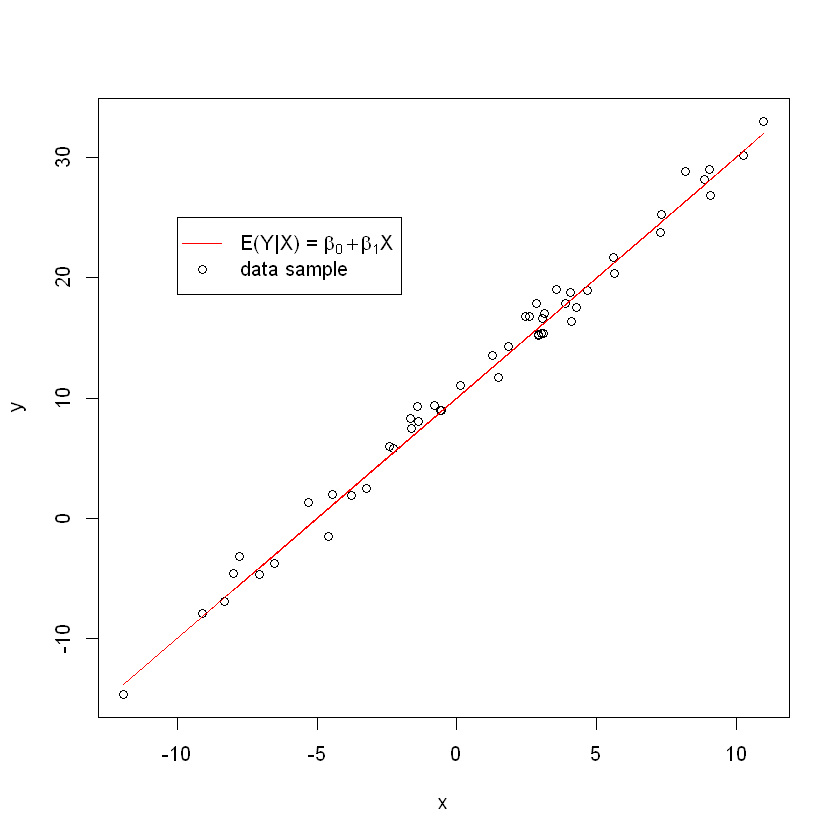

```r
plot(x = x, y = y)
lines(x = x, y = y_ce, col = "red")
legend(x = -10, y = 25,
       legend = c(expression(paste("E(Y|X) = ", beta[0] + beta[1] * X)),
                  "data sample"),
       lty = c(1, NA), lwd = c(1, NA), pch = c(NA, 1), col = c("red", "black"))
```

We see that, on average, the conditional expectation captures the relationship between $Y$ and $X$. Since we do not measure all the other variables (which are then consequently gathered in $\epsilon$ ) we see that the data sample values are scattered around the conditional mean of the process.

### Parameter Terminology

In general, we do not know the underlying true values of the coefficients $\beta_{0}$ and $\beta_{1}$. We will denote $\widehat{\beta}_{1}$ - the estimation of the unknown parameter $\beta_{1}$. We note that we can talk about $\widehat{\beta}_{1}$ in two ways:

- $\widehat{\beta}_{1}$ as a concrete estimated value, or more generally, as a result. Then we say that $\widehat{\beta}_{1}$ is an estimate of $\beta_{1}$ based on an observed data sample;
- $\widehat{\beta}_{1}$ as a random variable, or more generally, as a rule for calculating an estimate based on observed data. Then we say that $\widehat{\beta}_{1}$ is an estimator of $\beta_{1}$. When we are talking about $\widehat{\beta}_{1}$ as an estimator, we can also talk about its mean, $\mathbb{E}\left(\widehat{\beta}_{1}\right)$, variance $\operatorname{Var}\left(\widehat{\beta}_{1}\right)$ and distribution, which are very important when determining if a particular estimation method is better than an alternative one.

**Alternate notation:** You may also see the notation $\alpha \equiv \beta_0$ and $\beta_1 \equiv \beta$ with the corresponding estimates as $a \equiv \hat\beta_0$ and $b \equiv \hat \beta_1$. (Greene textbook for instance)

## Ordinary Least Squares (OLS)

The method of ordinary least squares (OLS) produces estimates **under certain conditions**. Let our (random) samples of $\epsilon, X$ and $Y$ be: $\varepsilon=\left(\epsilon_{1}, \ldots, \epsilon_{N}\right)^{\top}, \mathbf{X}=\left(X_{1}, \ldots, X_{N}\right)^{\top}$, and $\mathbf{Y}=\left(Y_{1}, \ldots, Y_{N}\right)^{\top}$

### Key assumptions in Regression Analysis

The required conditions are summarized in Greene table 2.1:

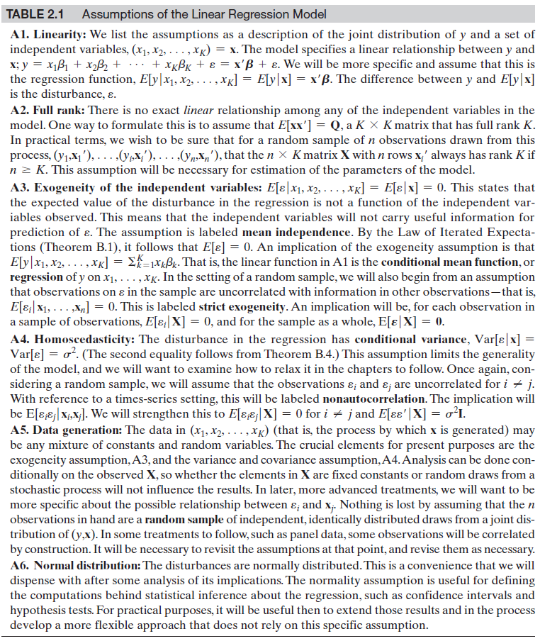

Or the summary version, Greene table 4.1:

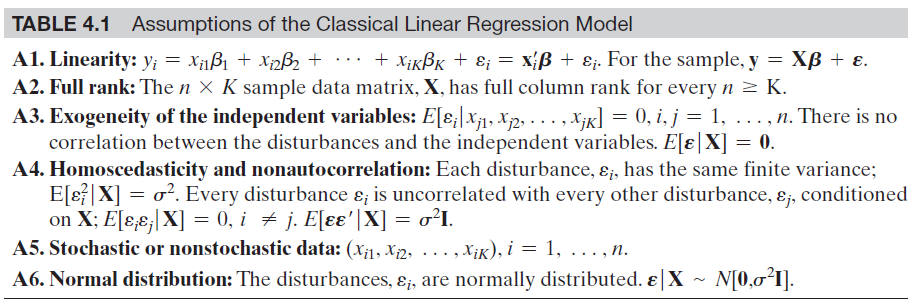

## Derivation of the Ordinary Least Squares Estimator

### Method of Moments (MM) Method

See prof. Nandi's notes.

### OLS - System of Partial Derivatives Method

**Crash course in optimization**:

Find the critical point(s) of function f defined by: $$ f(x, y)=x^{2}+y^{2} $$ We first find the first order partial derivatives: $$ f_{x}\equiv\frac{\partial f}{\partial x}=2 x, \quad f_{y}\equiv\frac{\partial f}{\partial y}=2 y $$ We now solve the following equations $f_{x}(x, y)=0$ and $f_{y}(x, y)=0$ simultaneously. $$ \begin{aligned} &f_{x}(x, y)=2 x=0 \\ &f_{y}(x, y)=2 y=0 \end{aligned} $$ The solution to the above system of equations is the ordered pair $(0,0)$.

Below is the graph of $f(x, y)=x^{2}+y^{2}$ and it looks that at the critical point $(0,0) f$ has a minimum value.

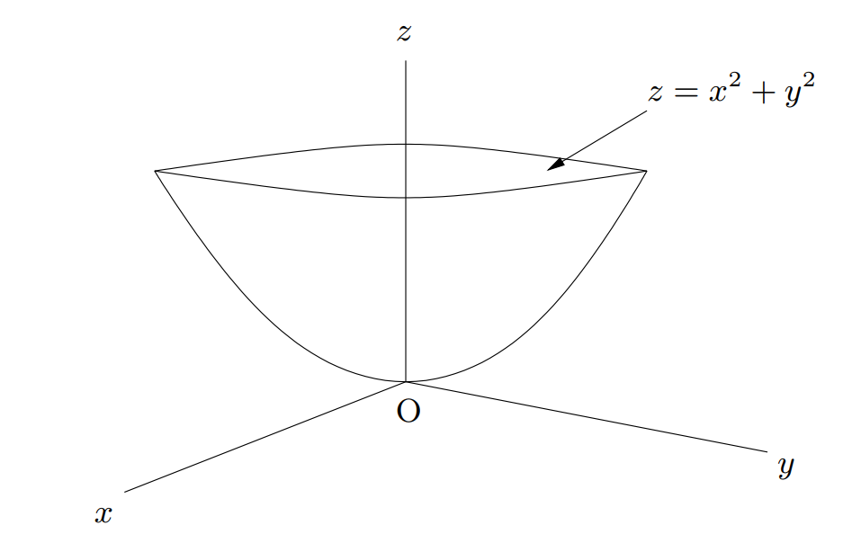

#### OLS Estimator Derivation

The mathematical problem is straightforward:

- Given a set of n points $\left(\mathrm{X}_{\mathrm{i}}, \mathrm{Y}_{\mathrm{i}}\right)$ on a scatterplot
- find the best-fit line, $\hat{Y}_{i}=\hat\beta_0+\hat\beta_1X_{i}$
- Such that the sum of squared errors in $\mathrm{Y}, \sum\left(Y_{i}-\hat{Y}_{i}\right)^{2}$ is minimized

The derivation proceeds as follows: for convenience, name the sum of squares "Q", \begin{equation} \min _{\hat\beta_0, \hat\beta_1} Q=\sum_{i=1}^{n}\left(Y_{i}-\hat{Y}\right)^{2}=\sum_{i=1}^{n}\left(Y_{i}-\hat\beta_0-\hat\beta_1 X_{i}\right)^{2} \end{equation}

Then, $\mathrm{Q}$ will be minimized at the values of $\mathrm{\hat\beta_0}$ and $\mathrm{\hat\beta_1}$ for which $\partial Q / \partial \hat\beta_0=0$ and $\partial Q / \partial \hat\beta_1=0$. The first of these conditions is, \begin{equation} \frac{\partial Q}{\partial \hat\beta_0}=\sum_{i=1}^{n}-2\left(Y_{i}-\hat\beta_0-\hat\beta_1 X_{i}\right)=2\left(n \hat\beta_0+\hat\beta_1 \sum_{i=1}^{n} X_{i}-\sum_{i=1}^{n} Y_{i}\right)=0 \end{equation}

which, if we divide through by 2 and solve for $\hat\beta_0$, becomes simply, \begin{equation} \hat\beta_0=\bar{Y}-\hat\beta_1 \bar{X} \end{equation} which says that **the constant $\hat\beta_0$ (the $\mathrm{y}$-intercept) is set such that the line must go through the mean of $\mathrm{x}$ and $\mathrm{y}$.** This makes sense, because this point is the "center" of the data cloud.

The second condition for minimizing $\mathrm{Q}$ is, \begin{equation} \frac{\partial Q}{\partial \hat\beta_1}=\sum_{i=1}^{n}-2 X_{i}\left(Y_{i}-\hat\beta_0-\hat\beta_1 X_{i}\right)=\sum_{i=1}^{n}-2\left(X_{i} Y_{i}-\hat\beta_0 X_{i}-\hat\beta_1 X_{i}^{2}\right)=0 \end{equation} If we substitute the expression for $\hat\beta_0$ from (3) into (4), then we get,

\begin{equation} \sum_{i=1}^{n}\left(X_{i} Y_{i}-X_{i} \bar{Y}+\hat\beta_1 X_{i} \bar{X}-\hat\beta_1 X_{i}^{2}\right)=0 \end{equation}

We can separate this into two sums, \begin{equation} \sum_{i=1}^{n}\left(X_{i} Y_{i}-X_{i} \bar{Y}\right)-\hat\beta_1\sum_{i=1}^{n}\left(X_{i}^{2}-X_{i} \bar{X}\right)=0 \end{equation} which becomes directly, \begin{equation} \hat\beta_1=\frac{\sum_{i=1}^{n}\left(X_{i} Y_{i}-X_{i} \bar{Y}\right)}{\sum_{i=1}^{n}\left(X_{i}^{2}-X_{i} \bar{X}\right)}=\frac{\sum_{i=1}^{n}\left(X_{i} Y_{i}\right)-n \bar{X} \bar{Y}}{\sum_{i=1}^{n}\left(X_{i}^{2}\right)-n \bar{X}^{2}} \end{equation}

We can translate (7) into a more intuitively obvious form, by noting that \begin{equation} \sum_{i=1}^{n}\left(\bar{X}^{2}-X_{i} \bar{X}\right)=0 \quad \text { and } \quad \sum_{i=1}^{n}\left(\bar{X} \bar{Y}-Y_{i} \bar{X}\right)=0 \end{equation} so that $\hat\beta_1$ can be rewritten as the ratio of $\operatorname{Cov}(x, y)$ to $\operatorname{Var}(x)$ : \begin{equation} \hat\beta_1=\frac{\sum_{i=1}^{n}\left(X_{i} Y_{i}-X_{i} \bar{Y}\right)+\sum_{i=1}^{n}\left(\bar{X} \bar{Y}-Y_{i} \bar{X}\right)}{\sum_{i=1}^{n}\left(X_{i}^{2}-X_{i} \bar{X}\right)+\sum_{i=1}^{n}\left(\bar{X}^{2}-X_{i} \bar{X}\right)} =\frac{\frac{1}{n} \sum_{i=1}^{n}\left(X_{i}-\bar{X}\right)\left(Y_{i}-\bar{Y}\right)}{\frac{1}{n} \sum_{i=1}^{n}\left(X_{i}-\bar{X}\right)^{2}} =\frac{\operatorname{Cov}(X, Y)}{\operatorname{Var}(X)} \end{equation}

**Intuition: Intercept**

As we saw above, the implication of equation (3) is that $\hat\beta_0$ (the y -intercept) is set such that the line must go through the mean of x and y.

Another way to think about it is that the least-squares line is a seesaw anchored at the center of the cloud. Once we find slope $\hat\beta_1$ (which minimizes the sum of squared deviations), the y-intercept is incidental to whatever slope was determined to be optimal.

To illustrate this, let's first generate some data with our DGP (data generating process) as follows:

- $\beta_{0}=10, \beta_{1}=0.5$
- $X_{i}=i-1, \epsilon_{i} \sim \mathcal{N}\left(0,1^{2}\right), i=1, \ldots, 51$

'Mean of x 25'

'Mean of y 22.02'

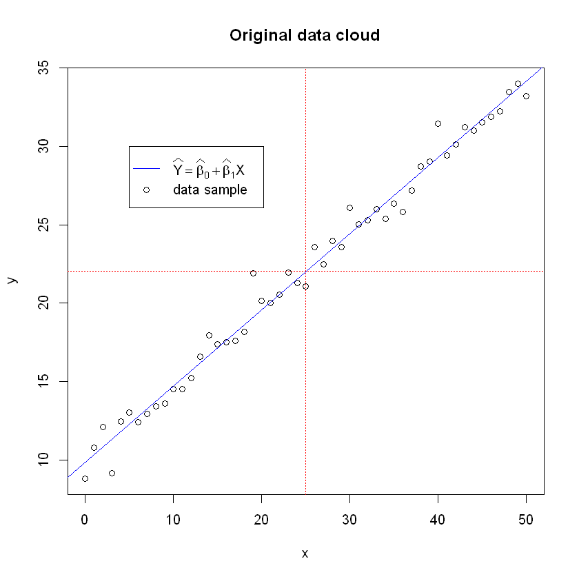

```r
set.seed(1234)
# Set the coefficients:
N = 50
beta_0 = 10
beta_1 = 0.5
# Generate sample data:
x <- 0:N
#
e <- rnorm(mean = 0, sd = 1, n = length(x))
y <- beta_0 + beta_1 * x + e
# Plot the data
x.bar<-mean(x)
paste0("Mean of x ",round(x.bar,2))
y.bar<-mean(y)
paste0("Mean of y ",round(y.bar,2))
plot(x,y,main="Original data cloud")
abline(h=y.bar,v=x.bar,col="red", lty=3)
abline(lm(y ~ x), col="blue")
legend(x = 5, y = 30,
       legend = c(expression(paste(widehat(Y) == widehat(beta)[0] + widehat(beta)[1] * X)),
                  "data sample"),
       lty = c(1, NA), lwd = c(1, NA), pch = c(NA, 1), col = c("blue", "black"))
```

We can "shift" our data cloud to be centered at the origin (i.e. "de-mean" our data) by subtracting the means from X and Y respectively.

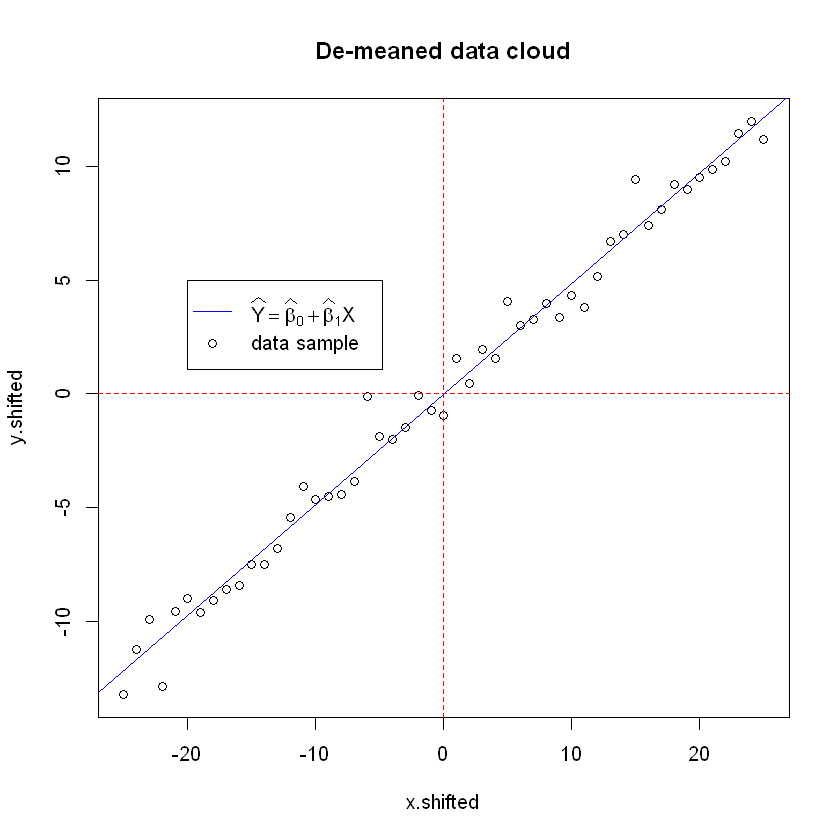

```r
x.shifted <- x-x.bar
y.shifted <- y-y.bar
plot(x.shifted,y.shifted,main="De-meaned data cloud")
abline(h=0,v=0,col="red", lty=2)
abline(lm(y.shifted ~ x.shifted), col="blue")
legend(x = -20, y = 5,
       legend = c(expression(paste(widehat(Y) == widehat(beta)[0] + widehat(beta)[1] * X)),
                  "data sample"),
       lty = c(1, NA), lwd = c(1, NA), pch = c(NA, 1), col = c("blue", "black"))
```

The estimated slope coefficients $\hat \beta_1$ are:

```r
beta_1_hat_original <- cov(x,y)/var(x)
beta_1_hat_shifted <- cov(x.shifted,y.shifted)/var(x.shifted)
paste("Slope coefficient estimate for original data set:",round(beta_1_hat_original,4))
paste("Slope coefficient estimate for de-meaned data set:",round(beta_1_hat_shifted,4))
```

'Slope coefficient estimate for original data set: 0.4856'

'Slope coefficient estimate for de-meaned data set: 0.4856'

So although we moved the center of the data cloud, the slope estimate remained the same. Which means that, alternately, we can think of the OLS procedure as:

1. "De-mean" our data to origin i.e. shift center to (0,0)
2. Calculate the slope $\hat\beta_1$ of the OLS line the minimizes the squared deviations
3. Shift everything back to the initial data cloud center
4. What is the y-intercept now? $\hat\beta_0=\bar{Y}-\hat\beta_1 \bar{X}$

See also Greene Figure 3.4 for the graphical intuition:

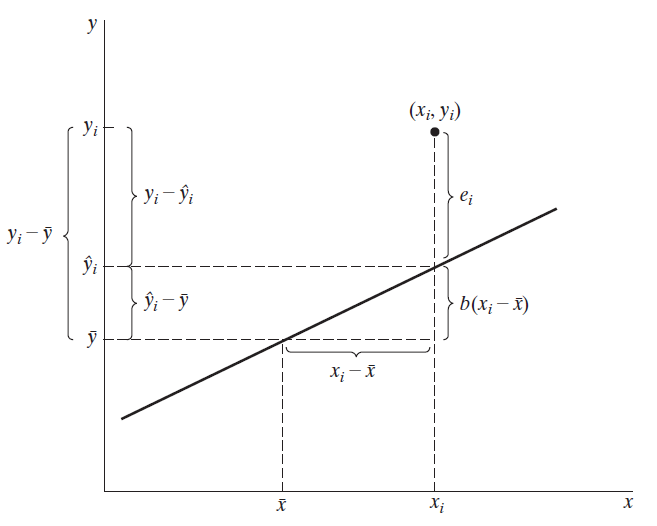

**Takeaways**:

- $\beta_{0}$, the intercept parameter,is not very useful and often has no econometric meaning, especially if $X$ cannot take a zero value (e.g. if $X$ is wage ). In machine learning it is called "the bias" term in the sense that it is the link to the center our our data cloud: the data variance (the important signal) happens around this bias level.
- However, in software, you should never run a regression without an intercept term: that option forces a 0 intercept and will result in a biased estimate of the slope coefficient.
- The estimate for $\hat\beta_1$ is quite close to the actual parameter $\beta_{1}=0.5$ that we used in the DGP. We will look at what "close" means in the statistical sense a bit later in the course.

#### Intuition: Regression Coefficient vs Correlation Coefficient

Recall that the correlation coefficient is: $$ \rho_{X, Y}=\frac{\operatorname{Cov}(X, Y)}{\sigma_{X} \sigma_{Y}} $$

where $\sigma_{X}=\sqrt{Var(X)}$ and $\sigma_{Y}=\sqrt{Var(Y)}$

We've established that the slope coefficient for univariate regression is: $$ \hat\beta_1=\frac{\operatorname{Cov}(X, Y)}{\operatorname{Var}(X)} \equiv \frac{\operatorname{Cov}(X, Y)}{\sigma_{X} \sigma_{X}} $$

Which implies the following relationship between the regression slope coefficient and the correlation coefficient: $$ \hat\beta_1=\rho_{X, Y}\frac{\sigma_Y}{\sigma_X} $$